# Prediction Assignment

Brad Simon

8 June 2018

## Practical Machine Learning: Prediction Assignment

One thing that people regularly do is quantify how much of a particular activity they do, but they rarely quantify how well they do it. In this project, the goal will be to use data from accelerometers on the belt, forearm, arm, and dumbell of 6 participants to determine how well the participant performed the barbell lift. They were asked to perform barbell lifts correctly and incorrectly in 5 different ways.

The data for this project comes from this source: http://web.archive.org/web/20161224072740/http:/groupware.les.inf.puc-rio.br/har.

### Read in and Clean dataset

The data set contains a number of columns that just summarise the previous values. These columns result in a number of NA Values and are generally unnecesary for our purposes asd any variance that they could help describe would be already accounted for by the other variables. As a result we will remove these columns for the purpose of building our model. There are also a number of columns of meta data that do not have any predictive value but rather describe the collection of the data (time and date, name of participant etc.) These columns will also be removed.

```r
#read in the data
df<- read.csv("H://Coursera/Machine_Learning/pml-training.csv", stringsAsFactors = TRUE)
#remove summary columns / missing values
df<- df[,c(1:11,37:49,60:68,84:86, 100:160)]
df<- df[,c(1:36,39,50:61,77,88:97)]

#remove Metadata Columns (times, Identifyers etc)

df<- df[,8:60]
```

### Create Data particion for cross validation

In order to validate the model the data has been split into 2 data sets. A training and a test set. The model will be trained on the training set and the test set will only be used to validate the model once it has been finalised.

```r
library(caret)
set.seed(13)
inTrain <- createDataPartition(df$classe, p=0.7, list = FALSE)
training <- df[inTrain,]
testing <- df[-inTrain,]
rm(inTrain)
```

### Generate models including all variables:

Here I will look at 3 different methods to build my model. 1. multinomial 2. rpart 3. random forest

```r
library(nnet)
library(rpart)
library(randomForest)

fit1<- multinom(classe~., data = training)
fit2<- train(classe~., data = training, method = "rpart")
fit3<- randomForest(classe~., data = training)
```

### Building in sample predictions and error rates to compare models

Here we build predictions based on the training set to find our in sample error rates for comparison.

```r
pred1<- predict(fit1, newdata = training)
pred2<- predict(fit2, newdata = training)
pred3<- predict(fit3, newdata = training)

cfm1<- confusionMatrix(pred1, training$classe)
cfm2<- confusionMatrix(pred2, training$classe)
cfm3<- confusionMatrix(pred3, training$classe)

cfm1$table
```

```
##           Reference
## Prediction    A    B    C    D    E
##          A 3221  379  335  174  150
##          B   83 1394  311   73  322
##          C  158  217 1401  250  208
##          D  371  266  263 1671  405
##          E   73  402   86   84 1440
```

```r
cfm1$overall
```

```
##       Accuracy          Kappa  AccuracyLower  AccuracyUpper   AccuracyNull
##   6.644100e-01   5.748340e-01   6.564431e-01   6.723072e-01   2.843416e-01
## AccuracyPValue  McnemarPValue
##   0.000000e+00  2.916496e-154
```

```r
cfm1$table
```

```
##           Reference
## Prediction    A    B    C    D    E
##          A 3221  379  335  174  150
##          B   83 1394  311   73  322
##          C  158  217 1401  250  208
##          D  371  266  263 1671  405
##          E   73  402   86   84 1440
```

```r
cfm1$overall
```

```
##       Accuracy          Kappa  AccuracyLower  AccuracyUpper   AccuracyNull
##   6.644100e-01   5.748340e-01   6.564431e-01   6.723072e-01   2.843416e-01
## AccuracyPValue  McnemarPValue
##   0.000000e+00  2.916496e-154
```

```r
cfm1$table
```

```
##           Reference
## Prediction    A    B    C    D    E
##          A 3221  379  335  174  150
##          B   83 1394  311   73  322
##          C  158  217 1401  250  208
##          D  371  266  263 1671  405
##          E   73  402   86   84 1440
```

```r
cfm1$overall
```

```
##       Accuracy          Kappa  AccuracyLower  AccuracyUpper   AccuracyNull
##   6.644100e-01   5.748340e-01   6.564431e-01   6.723072e-01   2.843416e-01
## AccuracyPValue  McnemarPValue
##   0.000000e+00  2.916496e-154
```

### Choose model and test on the testing data set

```r
library(RColorBrewer)

predtest<- predict(fit3, newdata = testing)

cfmtest<- confusionMatrix(predtest, testing$classe)
cfmtest$table
```

```
##           Reference
## Prediction    A    B    C    D    E
##          A 1674    4    0    0    0
##          B    0 1129    4    0    0
##          C    0    6 1022   11    0
##          D    0    0    0  953    0
##          E    0    0    0    0 1082
```

```r
cfmtest$overall
```

```
##       Accuracy          Kappa  AccuracyLower  AccuracyUpper   AccuracyNull
##      0.9957519      0.9946262      0.9937353      0.9972490      0.2844520
## AccuracyPValue  McnemarPValue
##      0.0000000            NaN
```

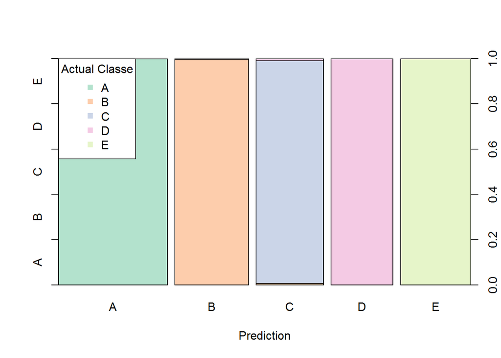

```r
plot(predtest, testing$classe, xlab = "Prediction", ylab = "", yaxt = 'n',col = brewer.pal(5, "Pastel2"))
legend("topleft", c("A","B","C","D","E"), pch = 15,cex = 1,col = brewer.pal(5,"Pastel2"), title = "Actual Classe")
axis(side=2,labels=F)
```

The out of sample error rate is still less than 1% which is vert good. This model should be more than sufficient to predict how well the barbell lift is performed in most cases.